# Hmw II : SVD methods and Elections Data

# Élections néerlandaises, 2021-2025

Le système électoral législatif néerlandais (proportionnelle intégrale sans seuil) et la culture politique du pays fait que beaucoup de partis différents (15 en 2026) parviennent à avoir des sièges dans sa chambre basse, il peut donc être intéressant d’appliquer des techniques d’analyse de données aux élections auxquelles nous nous intéresserons : les élections législatives de 2021, 2023 et 2025, ainsi que les élections provinciales de 2023. Les données seront à l’échelle municipale (gemeenten).

Une succinte description des partis qui seront mentionnés :

- PS : gauche radicale
- GL-PvdA : gauche modérée (les deux partis GL et PvdA sont distincts en 2021, se présentent sur des listes unies au niveau national en 2023 et en 2025 ainsi que dans certaines provinces en 2023, et sont actuellement en cours de fusion)
- DENK : parti centré sur les intérêts des personnes issues de l’immigration, en particulier turques et marocaines
- D66 : centre-gauche social-libéral
- CDA, NSC : centre-droit démocrate chrétien
- VVD : droite libérale
- BBB : droite populiste, intérêts ruraux
- SGP : droite chrétienne protestante (très) conservatrice
- PVV, JA21 : extrême-droite

### Chargement et traitement des données électorales locales

## Carte des votes par parti, 2025

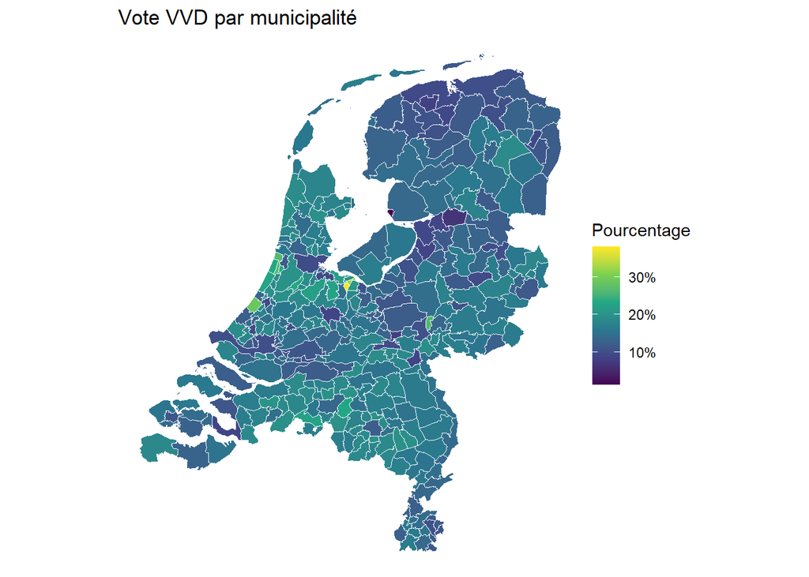

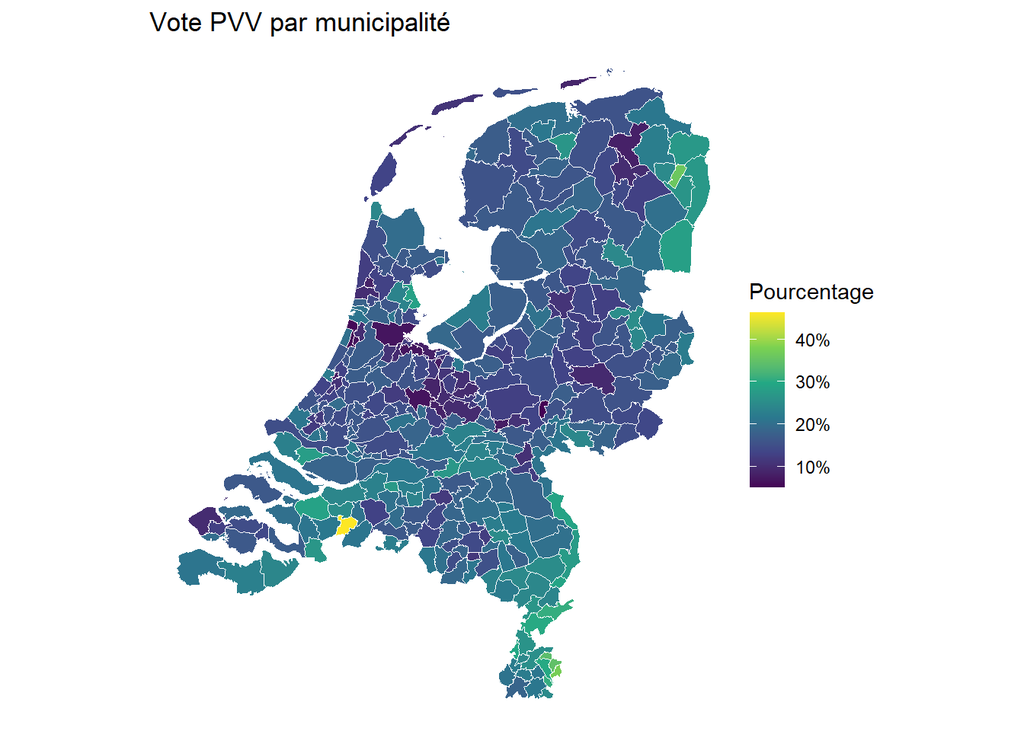

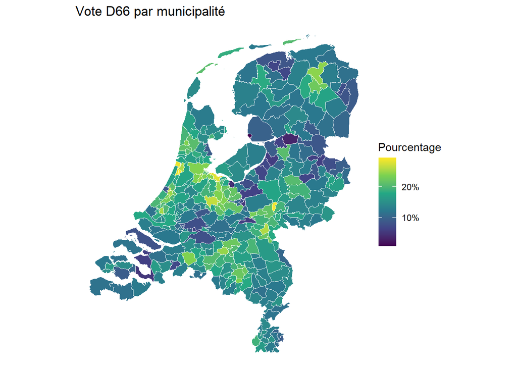

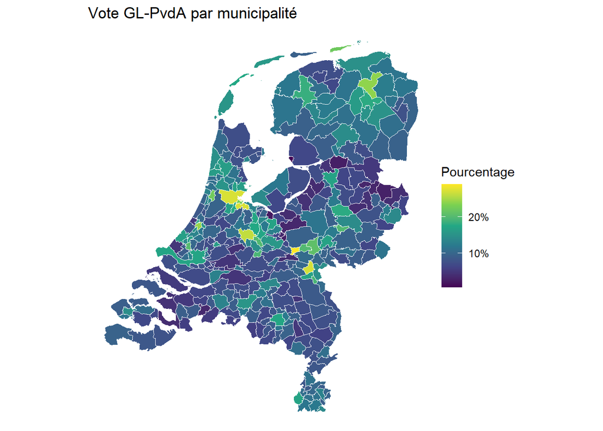

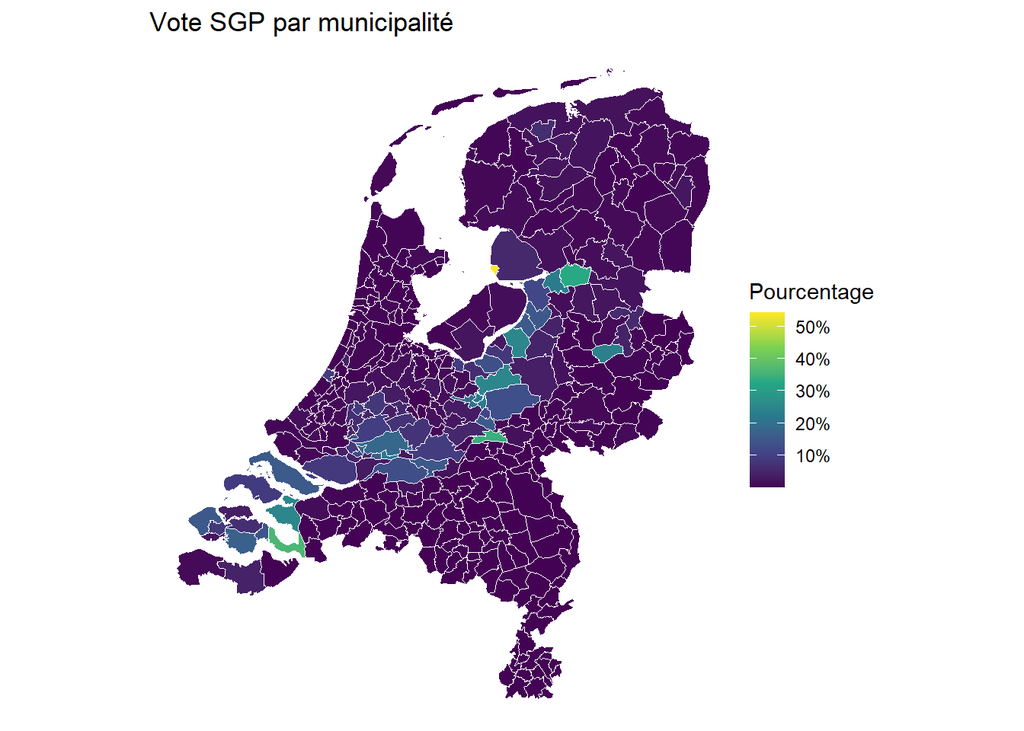

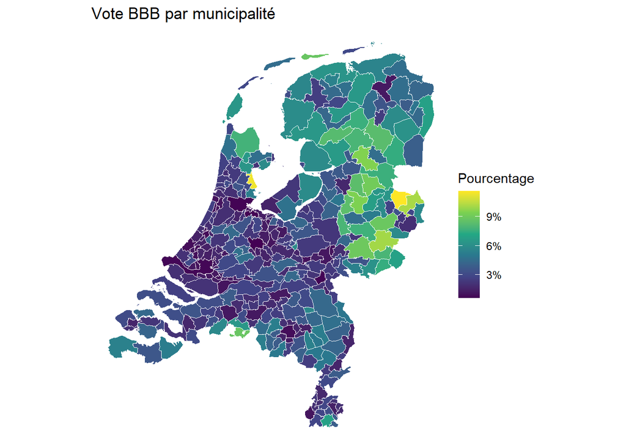

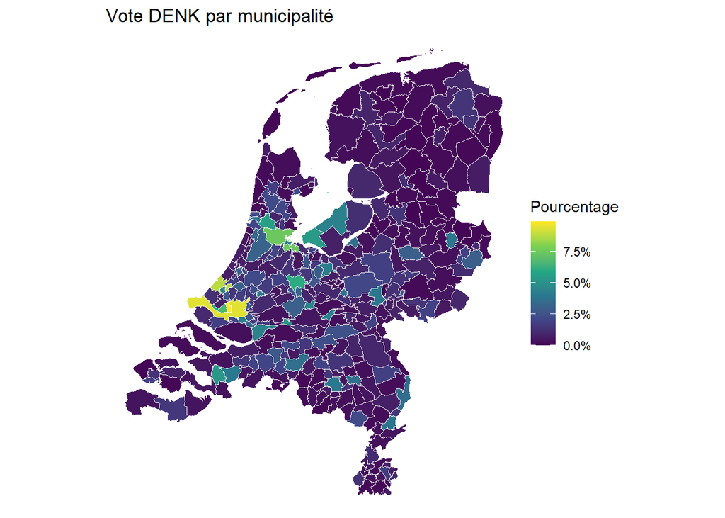

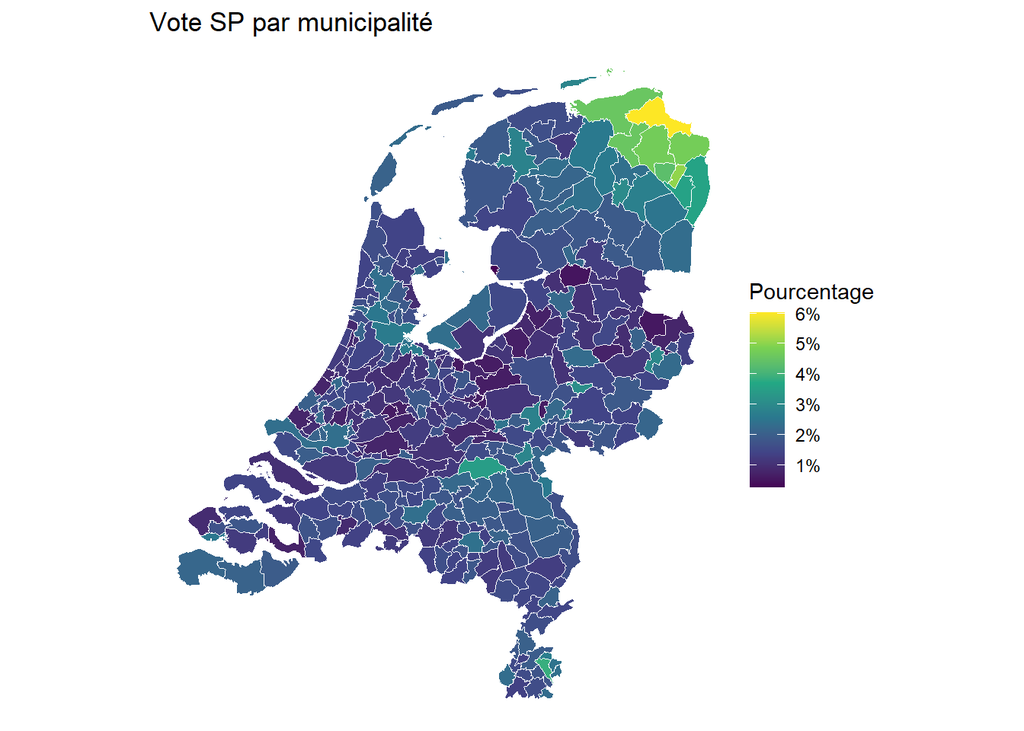

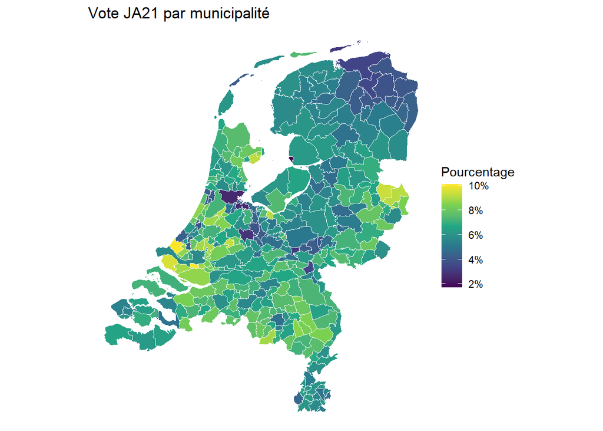

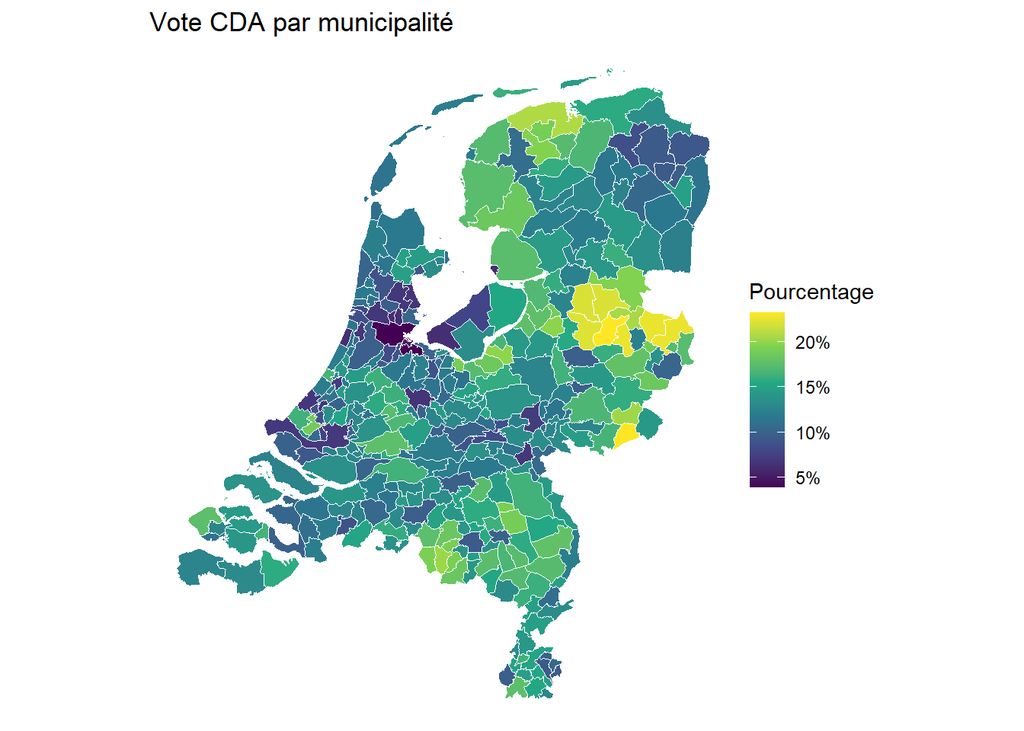

L’on remarque déjà certains motifs : des scores élevés de D66, GL-PvdA et DENK dans les grandes villes (GL-PvdA en particulier dans les villes universitaires), là où à l’inverse le BBB obtient des meilleurs résultats dans les régions agricoles du pays. Il faut aussi garder en tête la répartition du vote SGP, correspondant à la “Bible belt” néerlandaise, région caractérisée par une foi protestante élevée, qui reviendra dans cette présentation. L’on va confirmer ou infirmer toutes ces conjectures en faisant des analyses plus approfondies.

## Analyse en Composantes Principales, partie 1

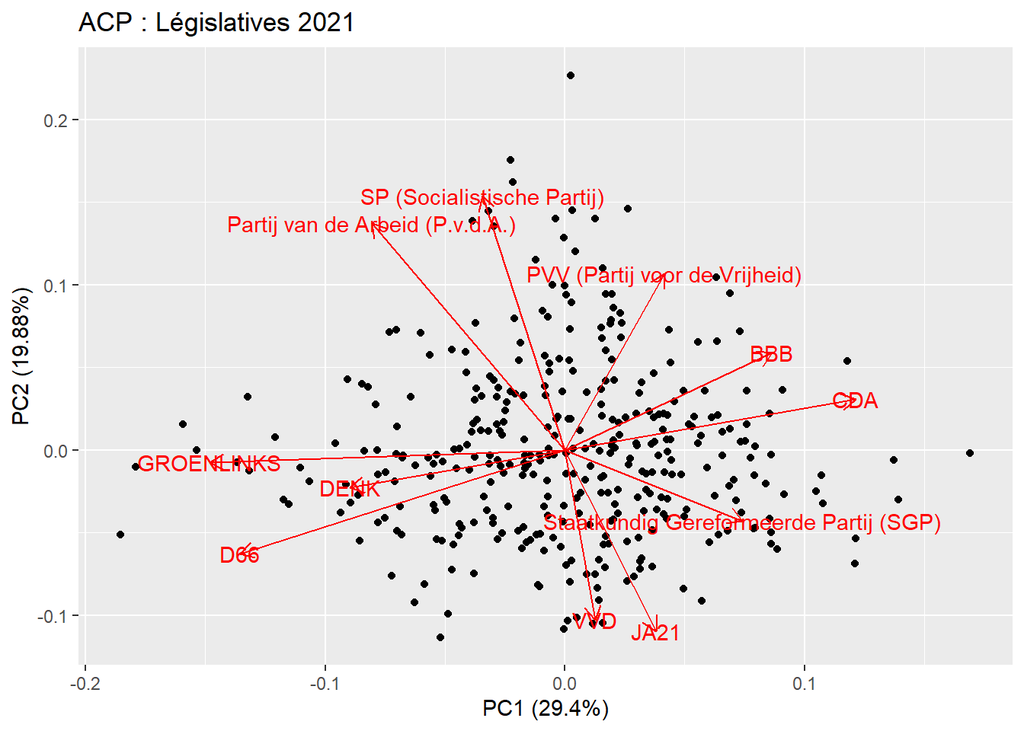

```
Importance of components:
                         PC1    PC2    PC3    PC4     PC5    PC6     PC7
Standard deviation     1.798 1.4788 1.3261 1.2663 0.84980 0.7764 0.59904
Proportion of Variance 0.294 0.1988 0.1599 0.1458 0.06565 0.0548 0.03262
Cumulative Proportion  0.294 0.4928 0.6527 0.7985 0.86413 0.9189 0.95155
                           PC8     PC9    PC10    PC11
Standard deviation     0.47633 0.45218 0.24274 0.20652
Proportion of Variance 0.02063 0.01859 0.00536 0.00388
Cumulative Proportion  0.97218 0.99077 0.99612 1.00000
```

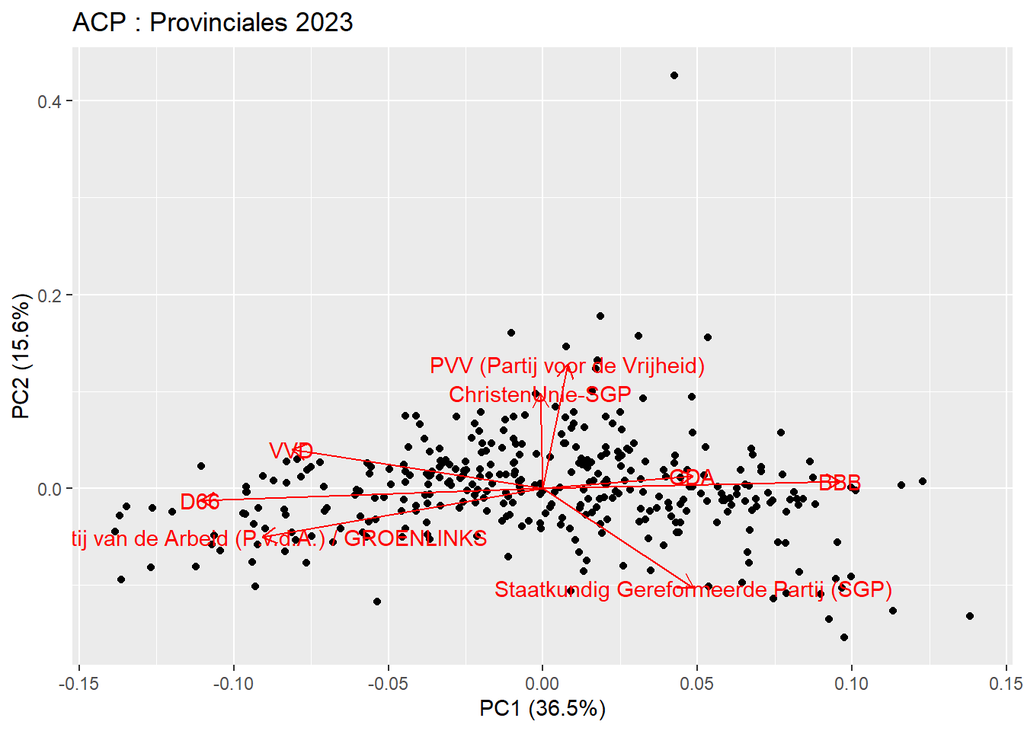

```
Importance of components:
                         PC1   PC2    PC3    PC4    PC5     PC6     PC7     PC8
Standard deviation     1.709 1.117 1.0193 0.9843 0.9057 0.87427 0.37132 0.31823
Proportion of Variance 0.365 0.156 0.1299 0.1211 0.1025 0.09554 0.01724 0.01266
Cumulative Proportion  0.365 0.521 0.6509 0.7720 0.8746 0.97011 0.98734 1.00000
```

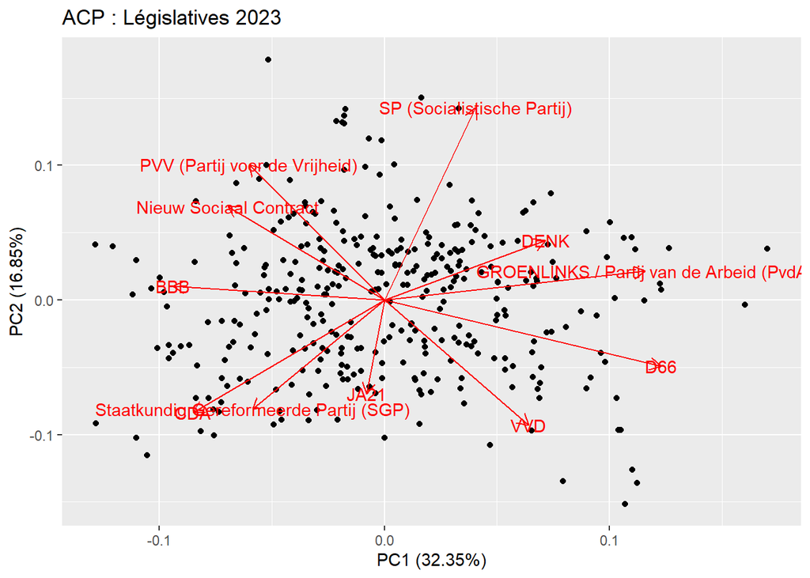

```
Importance of components:
                          PC1    PC2    PC3    PC4     PC5     PC6     PC7
Standard deviation     1.8864 1.3614 1.2533 1.2299 0.84630 0.76966 0.67863
Proportion of Variance 0.3235 0.1685 0.1428 0.1375 0.06511 0.05385 0.04187
Cumulative Proportion  0.3235 0.4920 0.6348 0.7723 0.83743 0.89128 0.93315
                           PC8     PC9    PC10    PC11
Standard deviation     0.62331 0.52776 0.23570 0.11299
Proportion of Variance 0.03532 0.02532 0.00505 0.00116
Cumulative Proportion  0.96847 0.99379 0.99884 1.00000
```

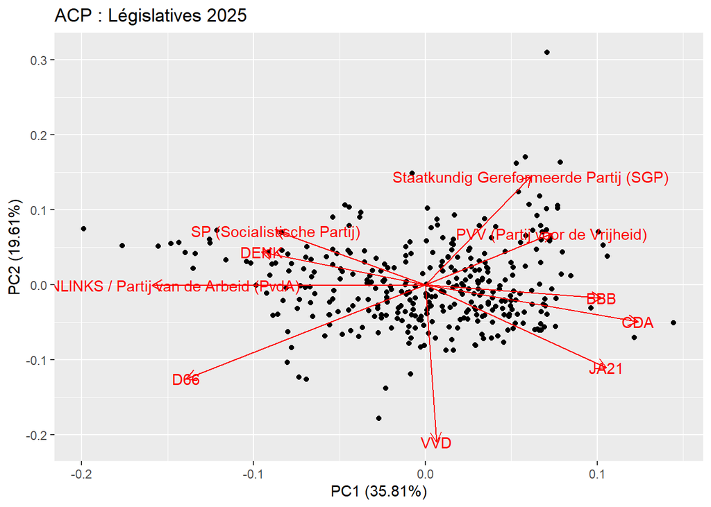

```
Importance of components:
                          PC1    PC2    PC3    PC4     PC5     PC6     PC7
Standard deviation     1.8924 1.4005 1.2053 1.1464 0.80636 0.65371 0.52953
Proportion of Variance 0.3581 0.1961 0.1453 0.1314 0.06502 0.04273 0.02804
Cumulative Proportion  0.3581 0.5543 0.6996 0.8310 0.89599 0.93872 0.96676
                          PC8    PC9    PC10
Standard deviation     0.4970 0.2588 0.13547
Proportion of Variance 0.0247 0.0067 0.00184
Cumulative Proportion  0.9915 0.9982 1.00000
```

Quelques remarques :

- Les deux premières composantes ne sont pas très significatives (environ 30-35% et 15-20% pour chaque ACP)
- Pour les législatives, on peut globalement tracer une droite entre les partis “de gauche” (SP,DENK,D66,GL,PvdA) et les partis “de droite” (CDA,NSC,VVD,SGP,JA21,PVV), cette droite n’est pas alignée avec les axes
- Les deux partis de gauche ayant ultérieurement fusionné (GL et PvdA) ne sont pas alignés géographiquement en 2021
- En 2021 : on pourrait conjecturer que l’axe des abscisses correspond grossièrement à un axe gauche droite, celui des ordonnées à un axe “élitiste” (VVD, D66 vers le bas) VS “populiste” (SP, PVV vers le haut)
- Les provinciales de 2023 sont assez peu lisibles, le VVD est à l’opposé des autres partis de droite, les votes se font possiblement sur d’autres critères que celui des législatives
- En 2023 : moins clair qu’en 2021, les partis “de droite” occupent le coin inférieur gauche, mais le PVV et le VVD sont opposés
- En 2025 : à l’exception du VVD, il y a une plus nette distinction entre les partis “de gauche” et ceux “de droite” que les années précédentes. Le VVD est géographiquement distribué de manière assez distincte.

## Analyse canonique des corrélations, 2023 VS 2025

```
 [1] 0.9992691 0.9964033 0.9931714 0.9836577 0.9778714 0.9218367 0.8731509
 [8] 0.8117005 0.7886489 0.6892144 0.2258929
```

```
 [1] 0.9985388 0.9928195 0.9863895 0.9675825 0.9562324 0.8497829 0.7623926
 [8] 0.6588577 0.6219671 0.4750165 0.0510276
```

```
              [,1]      [,2]      [,3]       [,4]       [,5]      [,6]
VVD     -0.7075621 -1.492794  2.491153 -15.626467   1.712076  11.53205
D66     -0.7785420  9.198309 -6.798586 -11.514228 -12.777429  14.67691
GL-PvdA -1.4106063  6.512352 -4.127380   9.529088 -13.271934  10.57449
PVV      0.6009183 -3.374130  7.515586  -1.788501 -16.035422  15.59666
CDA      1.5117412 -1.202069 -5.065196  14.456443  21.202168 -42.03639
SP      -0.2378307  5.253614 -4.665512   5.068631 -10.973856 -26.14298
Volt    -0.7681686  5.268881 -2.566594 -16.960041  -2.514470  56.01937
JA21    -3.2132696  2.079027  1.901400  21.296376  20.288521 -38.39214
SGP     15.5773061  6.626934 -1.024984  -4.123073  -9.072051  14.29247
DENK     0.3186230 29.988015 55.202825   7.675451  38.841284  21.60098
BBB     -0.1034070 -3.298478  0.093143   6.311336   4.168377  40.39565
               [,7]        [,8]        [,9]       [,10]     [,11]
VVD     -30.4834362    6.113892  -1.0223598   22.153191 -23.25767
D66      94.2449150   44.949066 -35.8536191 -120.539428  13.02690
GL-PvdA -40.4456165   -4.096908 -11.0952704   -4.225118 -28.99796
PVV       5.7371920   -5.040167 -16.3074835   -6.487184 -19.60675
CDA      11.9799070   -6.788986 -44.5070022   15.339046 -89.34819
SP       40.8155127   61.597258  90.6169611   47.876020 -57.47505
Volt    131.2139952 -153.176559  56.5690200  242.197453 -61.47590
JA21    -10.9560836 -359.425489 397.3068226 -393.518140 -79.12100
SGP       1.2036105    6.600927   0.2001018   -3.880146 -21.27764
DENK      0.3601472   18.363731 -15.0992583   -3.532925 -33.36189
BBB       6.2438509    8.333770  -1.7680283  -11.397729 -23.90755
```

```
              [,1]       [,2]       [,3]        [,4]       [,5]       [,6]
VVD     -0.2125252 -0.8431141   2.002524 -17.7572185   1.194085  17.031180
D66     -0.7753178  6.3710835  -3.908154  -5.1792428 -13.715375  16.874971
GL-PvdA -0.6491144  8.1758517  -5.511364  13.9867772 -14.864234  12.310369
PVV      0.7410160 -2.1031446   6.398874  -0.9358252 -20.601824  19.601178
CDA      0.6173846  1.1628686  -3.921330   5.9235962   6.372800  -4.498225
SP       0.8348269  3.9052012  -1.777133  13.3619225  -8.791991 -21.910990
Volt    -4.1423835 14.7164807 -18.261575 -69.9451377  13.432257 114.548941
JA21     1.6380486 -1.5250705   6.237905  -0.2159454 -10.729086   7.224711
SGP     15.0491699  7.4852603  -2.001173  -4.0306708 -10.521094  21.644843
DENK     0.6644899 30.5706513  54.672342   6.8049529  39.461184  31.191097
BBB     -0.1254977 -4.1135365  -1.532376  15.7849868   6.287505  71.137161
               [,7]       [,8]        [,9]       [,10]      [,11]
VVD     -29.1178704   28.76808  -3.8346443  29.9334858 -42.666130
D66      37.9993795   31.94758  -0.5852582 -39.7682442 -23.267869
GL-PvdA -56.3960244   19.79953 -15.5079896  -9.3268008 -79.394454
PVV       6.8786240   19.17528 -14.1498826   0.7411677 -43.918665
CDA       3.5746462   30.11701 -15.7527866  12.5701691 -64.496746
SP       44.1569741   96.20836 167.9799355  82.7509842 -52.875480
Volt    253.1255085 -212.38220  88.0078214 354.6963862   7.554972
JA21    -11.7527518  -33.95527  75.2876684 -40.9913690 -89.174652
SGP       0.9462741   26.86152   4.9567801  -0.1119692 -52.119137
DENK      1.0002248   44.00039 -15.4524520  15.3955659 -51.752010
BBB      16.7692005   25.28109   7.0779352 -17.0163555 -29.249117
```

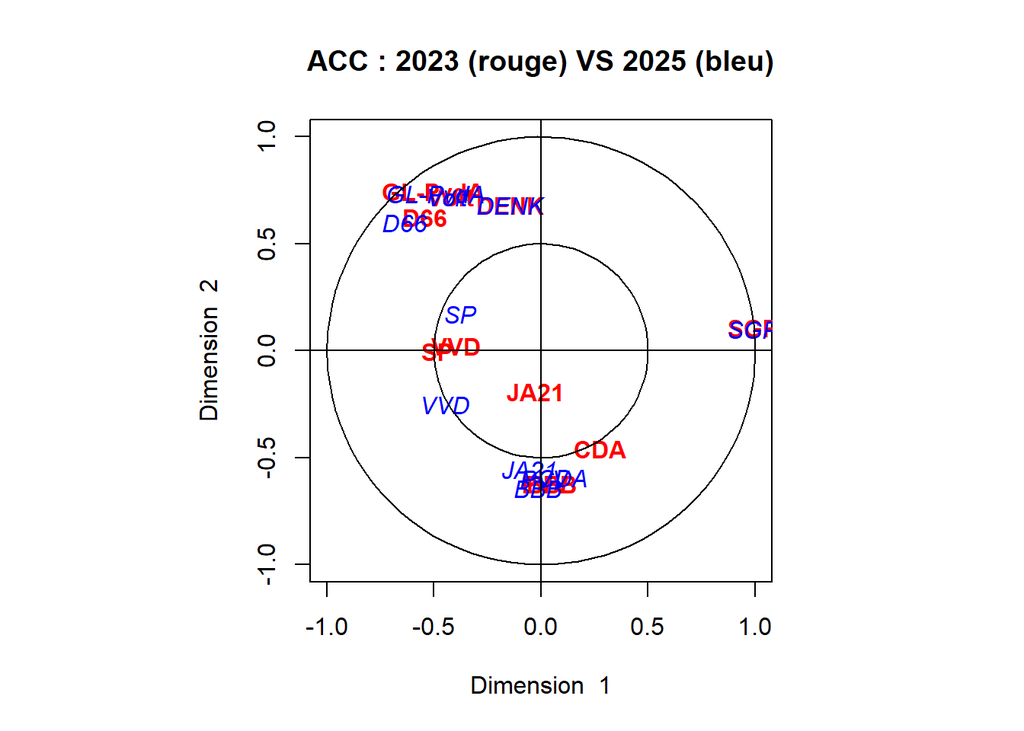

Certains partis d’ont pas subi trop de réalignement géographique : le SGP, DENK, GL-PvdA, D66, BBB C’est assez attendu dans le cas du SGP et de DENK, qui sont des petits partis aux électorats assez captifs.

D’autres partis ont été davantage réalignés : c’est en particulier le cas de JA21, qui a réalisé une percée en 2025 en “volant” des votes au PVV, ce qui pourrait expliquer son rapprochement.

## Régression linéaire

### Par parti, 2023 VS 2025

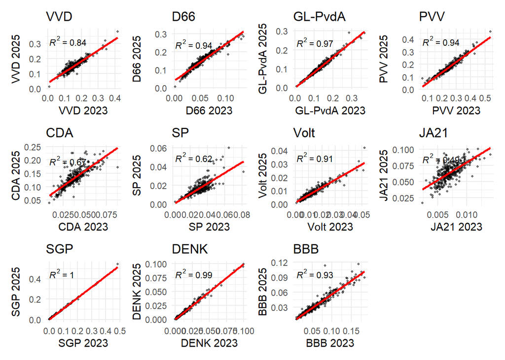

Les performances de certains partis en 2025 sont très bien prédites par celles de 2023 : c’est, comme on l’a vu précédemment, le cas de DENK et du SGP (R² de 1 !!!). Les partis pour lesquels c’est moins le cas sont ceux qui ont des résultats très différents de l’élection précédente : CDA (retour en force après la perte de la quasi-totalité de ses sièges en 2023), JA21 (percée significative), SP (contre-performance).

Malgré une augmentation significative du score de D66 en 2025, l’on remarque que son score est bien prédit par celui de 2023 : ce n’est pas un réalignement géographique, le parti a juste augmenté ses marges là où il faisait déjà ses meilleurs scores.

### Analyse : Fusion GL-PvdA, 2021 VS 2023

Comme nous l’avions expliqué, les deux partis de gauche modérée, GROENLINKS (“Gauche Verte”) et PvdA (Parti Travailliste) ont, malgré semble-t-il un éloignement non-négligeable d’après l’ACP des législatives de 2021 effectué une fusion de leurs listes au niveau national à partir de 2023 (les deux partis sont actuellement en discussion pour fusionner en un seul parti qui serait nommé “Progressief Nederland”). L’alliance a visiblement été fructueuse pour les élections de 2023 vu que la liste commune a obtenu un meilleur score que la somme des scores des deux partis en 2021, mais on peut l’analyser de plus près.

```
Call:
lm(formula = gl_pvda_2023 ~ gl_pvda_2021, data = reg_data2023)

Residuals:
     Min       1Q   Median       3Q      Max
-0.10340 -0.02916 -0.01051  0.01585  0.22008

Coefficients:
             Estimate Std. Error t value Pr(>|t|)
(Intercept)  0.048102   0.007603   6.327 7.98e-10 ***
gl_pvda_2021 1.448258   0.129900  11.149  < 2e-16 ***
---
Signif. codes:  0 '***' 0.001 '**' 0.01 '*' 0.05 '.' 0.1 ' ' 1

Residual standard error: 0.04756 on 336 degrees of freedom
Multiple R-squared:   0.27, Adjusted R-squared:  0.2679
F-statistic: 124.3 on 1 and 336 DF,  p-value: < 2.2e-16
```

```
Call:
lm(formula = gl_pvda_2025 ~ gl_pvda_2021, data = reg_data2025)

Residuals:
      Min        1Q    Median        3Q       Max
-0.079576 -0.023757 -0.008808  0.012741  0.162076

Coefficients:
             Estimate Std. Error t value Pr(>|t|)
(Intercept)  0.031511   0.005904   5.337 1.74e-07 ***
gl_pvda_2021 1.297515   0.100877  12.862  < 2e-16 ***
---
Signif. codes:  0 '***' 0.001 '**' 0.01 '*' 0.05 '.' 0.1 ' ' 1

Residual standard error: 0.03694 on 336 degrees of freedom
Multiple R-squared:  0.3299,    Adjusted R-squared:  0.3279
F-statistic: 165.4 on 1 and 336 DF,  p-value: < 2.2e-16
```

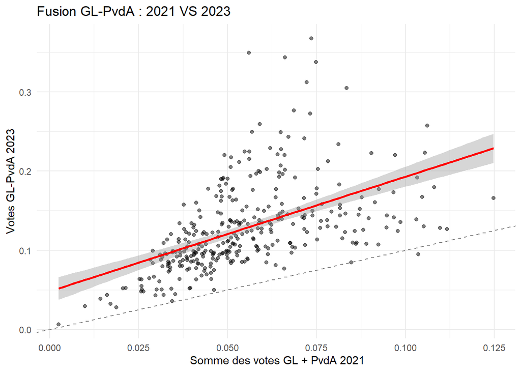

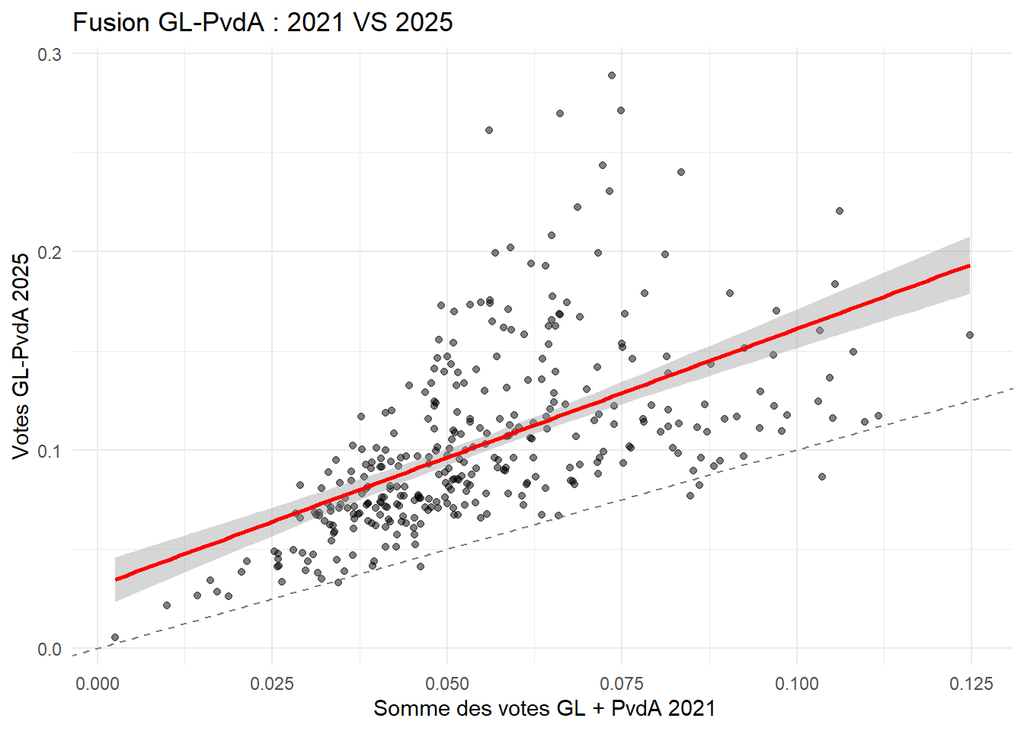

### Analyse : CDA et NSC, 2021-2023 et 2023-2025

Le CDA est un parti chrétien-démocrate historique. En 2023 est fondé le NSC (“Nouveau Contrat Social”) par d’anciens membres du CDA, qui obtient 20 sièges pour ses premières élections, aux dépens du CDA qui chute à 5 sièges. Le phénomène inverse advient deux ans plus tard, quand le NSC s’effondre et perd tous ses sièges là où le CDA remonte à 18. Les deux partis semblent donc partager le même électorat.

```
Call:
lm(formula = nsc_2023 ~ cda_2021, data = reg_cda_nsc)

Residuals:
      Min        1Q    Median        3Q       Max
-0.069058 -0.014309 -0.000885  0.010977  0.139102

Coefficients:
            Estimate Std. Error t value Pr(>|t|)
(Intercept) 0.057578   0.004288   13.43   <2e-16 ***
cda_2021    0.711423   0.035579   20.00   <2e-16 ***
---
Signif. codes:  0 '***' 0.001 '**' 0.01 '*' 0.05 '.' 0.1 ' ' 1

Residual standard error: 0.02711 on 336 degrees of freedom
Multiple R-squared:  0.5434,    Adjusted R-squared:  0.542
F-statistic: 399.8 on 1 and 336 DF,  p-value: < 2.2e-16
```

```
Call:
lm(formula = cda_2025 ~ nsc_2023, data = reg_nsc_cda)

Residuals:
      Min        1Q    Median        3Q       Max
-0.102362 -0.018961 -0.000708  0.018275  0.074297

Coefficients:
            Estimate Std. Error t value Pr(>|t|)
(Intercept) 0.062745   0.005444   11.53   <2e-16 ***
nsc_2023    0.512221   0.037910   13.51   <2e-16 ***
---
Signif. codes:  0 '***' 0.001 '**' 0.01 '*' 0.05 '.' 0.1 ' ' 1

Residual standard error: 0.0279 on 341 degrees of freedom
Multiple R-squared:  0.3487,    Adjusted R-squared:  0.3468
F-statistic: 182.6 on 1 and 341 DF,  p-value: < 2.2e-16
```

```
Call:
lm(formula = cda_2025 ~ cda_2021 + nsc_2023, data = reg_full)

Residuals:
      Min        1Q    Median        3Q       Max
-0.087301 -0.008985  0.000081  0.011092  0.051321

Coefficients:
             Estimate Std. Error t value Pr(>|t|)
(Intercept)  0.056781   0.003159  17.973  < 2e-16 ***
cda_2021     0.814924   0.031291  26.043  < 2e-16 ***
nsc_2023    -0.111947   0.032422  -3.453 0.000626 ***
---
Signif. codes:  0 '***' 0.001 '**' 0.01 '*' 0.05 '.' 0.1 ' ' 1

Residual standard error: 0.01611 on 335 degrees of freedom
Multiple R-squared:  0.7847,    Adjusted R-squared:  0.7834
F-statistic: 610.5 on 2 and 335 DF,  p-value: < 2.2e-16
```

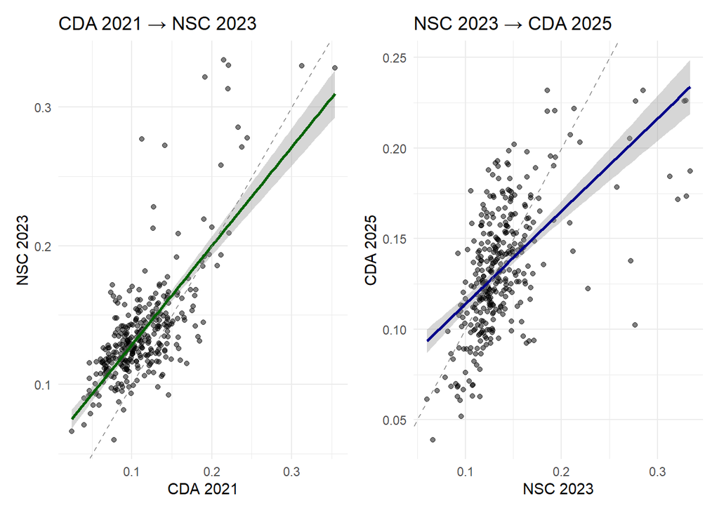

Plusieurs choses :

- Pour la régression 2021->2023, on a un R² de 0,54 (presque décent), donc une relation géographique relativement bonne, avec une pente de 0,71 : le NSC n’a pas donc su prendre tous les électeurs CDA de 2021
- Régression 2023->2025 : R² de 0,35 (moins bon), pente de 0,51 : le CDA n’a pas exactement repris tous les électeurs NSC.
- Régression prenant en compte 2021 ET 2023 : R² de 0,78 (meilleur que les autres) les scores du CDA en 2021 et du NSC en 2023 expliquent bien ceux du CDA en 2025. Curiosité : le coefficient pour le NSC en 2023 est négatif (-0,11) : on pourrait l’expliquer par le fait que des nouveaux électeurs NSC en 2023 ne sont pas partis vers le CDA en 2025.

## k-means

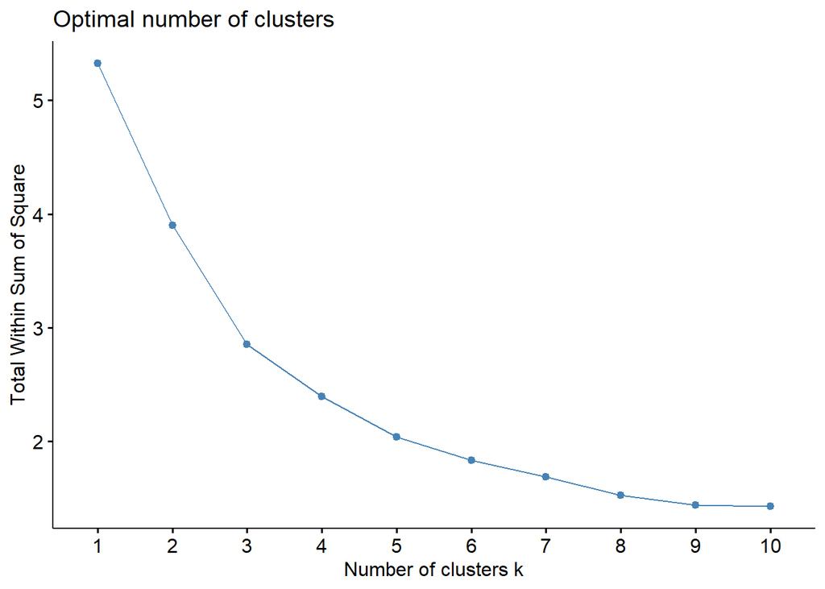

On va tester 3 et 5 clusters.

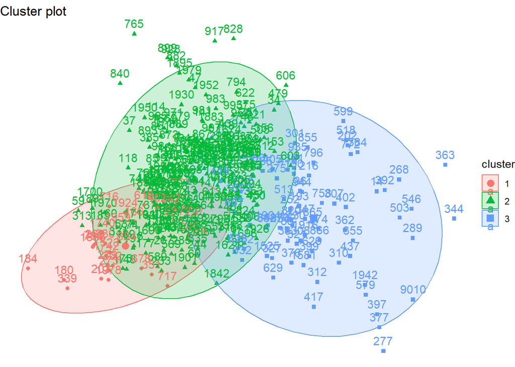

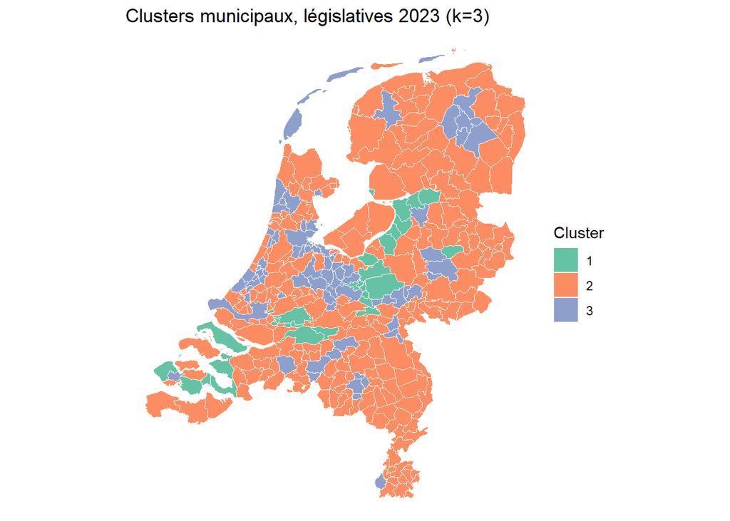

On observe trois clusters :

3 : Centres urbains

1 : Bible Belt

2 : “Le reste”

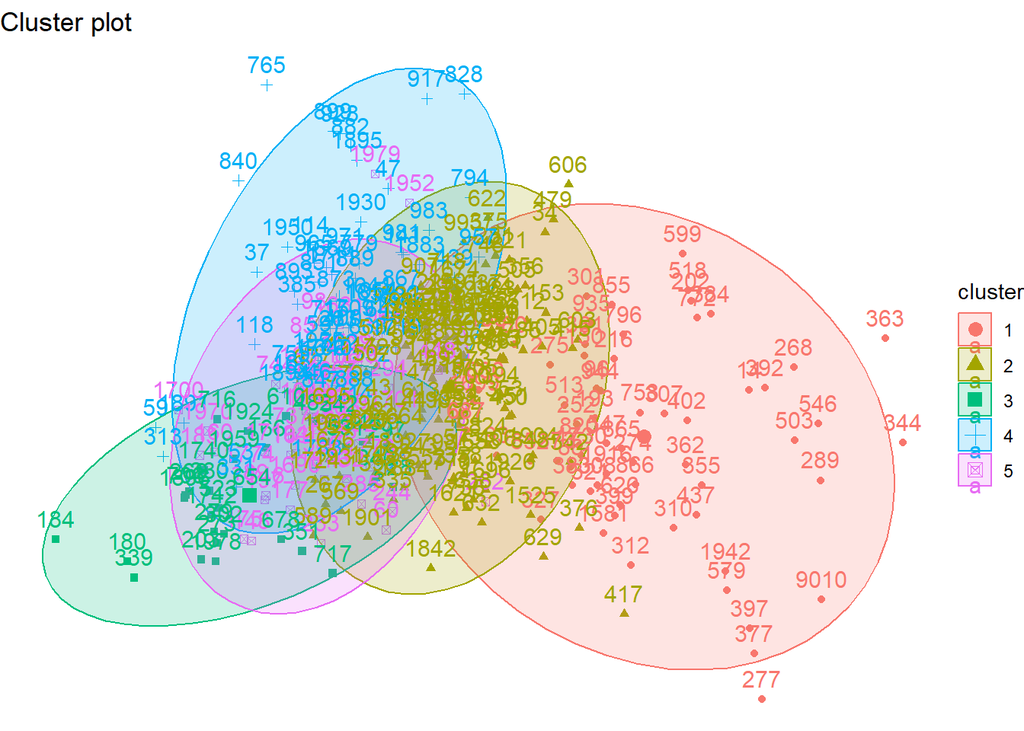

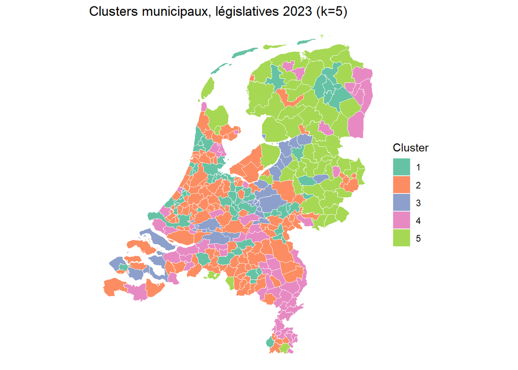

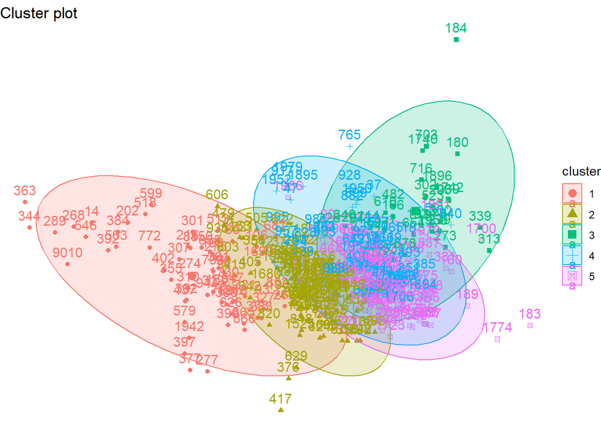

```
        VVD        D66    GL-PvdA       PVV        CDA         SP        Volt
1 0.1734288 0.09011585 0.21899703 0.1708698 0.02974985 0.03071626 0.025736602
2 0.1860412 0.05991854 0.12227346 0.2569908 0.03720060 0.03201338 0.013003043
3 0.1165377 0.02714605 0.06707109 0.2334667 0.04614535 0.01691273 0.006207954
4 0.1445692 0.03903880 0.09651481 0.3427763 0.03801874 0.03509143 0.007610912
5 0.1291521 0.03933786 0.10782358 0.2338403 0.04680012 0.02752269 0.008786531
         JA21         SGP        DENK        BBB
1 0.006229433 0.007212194 0.018746427 0.03093094
2 0.007886815 0.013348220 0.015808137 0.04840319
3 0.006806178 0.191115754 0.007187088 0.05820168
4 0.007066159 0.011625160 0.009315648 0.05926362
5 0.006361648 0.012574925 0.004314915 0.12114003
```

```
        VVD        D66    GL-PvdA       PVV       CDA         SP        Volt
1 0.1488991 0.22270120 0.17691586 0.1126650 0.1059049 0.01926082 0.016336348
2 0.1746464 0.17513542 0.10685458 0.1733464 0.1225301 0.01692355 0.008986208
3 0.1106810 0.07899659 0.05233459 0.1660547 0.1419737 0.00915905 0.003973813
4 0.1473001 0.12247934 0.08605699 0.2636863 0.1242257 0.02073785 0.005840944
5 0.1549333 0.12666038 0.07851949 0.1785898 0.1678039 0.01478353 0.006271780
        JA21         SGP        DENK        BBB
1 0.04795817 0.007797689 0.019182246 0.01846721
2 0.06865895 0.007781918 0.016929069 0.02561708
3 0.06038078 0.198398954 0.007332369 0.02867111
4 0.06543175 0.008861664 0.011427140 0.03341922
5 0.07067557 0.023824687 0.005815881 0.05526201
```

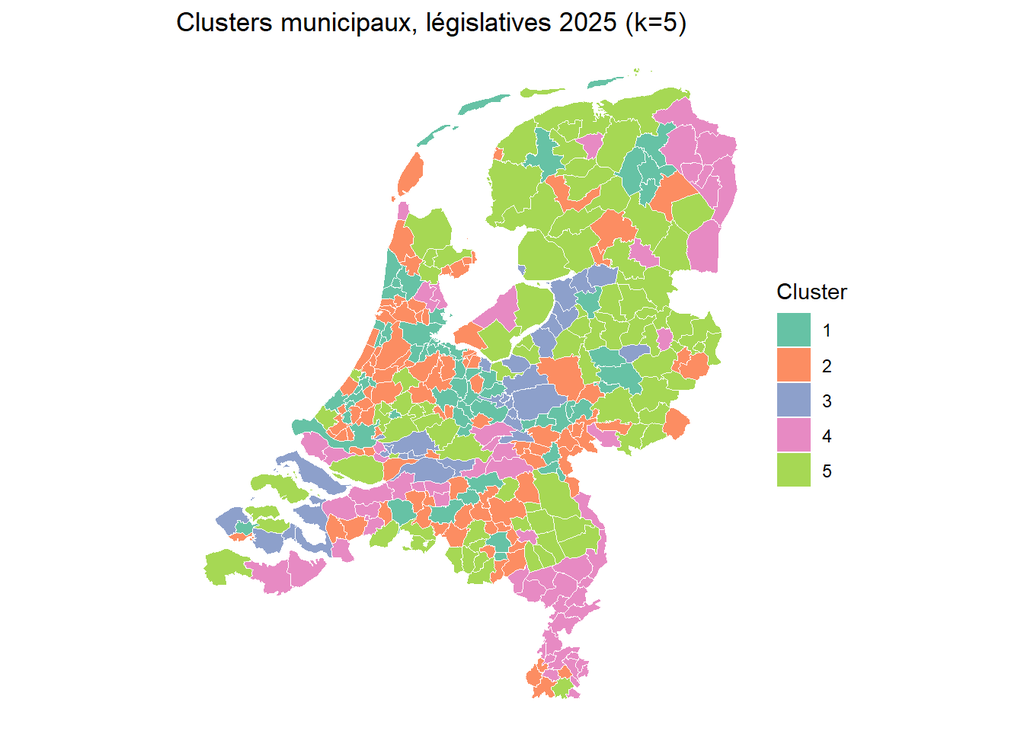

On observe les cinq clusters (changer le seed ne fait que permuter leur ordre) :

3 : La Bible Belt (SGP élevé)

1 : Les centres urbains (GL-PvdA élevé)

4 : Les places fortes du PVV

2 : Périphérie (PVV, VVD relativement élevés)

5 : Ruralité (BBB élevé en 2023, CDA élevé en 2025)

```
     1  2  3  4  5
  1 60  3  0  0  0
  2  0 94  0  5 33
  3  0  0 31  0  0
  4  0  1  1 53  9
  5  1  3  0  2 47
```

```
   Code cluster_2023 cluster_2025 switched                      statnaam
1  1680            1            2     TRUE                   Aa en Hunze
2   820            1            2     TRUE Nuenen, Gerwen en Nederwetten
3   935            1            2     TRUE                    Maastricht
4   995            2            4     TRUE                      Lelystad
5   281            2            4     TRUE                          Tiel
6   677            2            4     TRUE                         Hulst
7   994            2            4     TRUE        Valkenburg aan de Geul
8   988            2            4     TRUE                         Weert
9   147            2            5     TRUE                         Borne
10  173            2            5     TRUE                     Oldenzaal
11   50            2            5     TRUE                      Zeewolde
12 1960            2            5     TRUE                   West Betuwe
13  243            2            5     TRUE                    Harderwijk
14  267            2            5     TRUE                       Nijkerk
```

[output cut: 44 more lines]

L’on peut avoir accès aux municipalités passées d’un cluster à l’autre.

Les méthodes de clustering hiérarchiques ne sont pas meilleures, nous sommes cependant parvenus à un résultat décent avec ces paramètres :

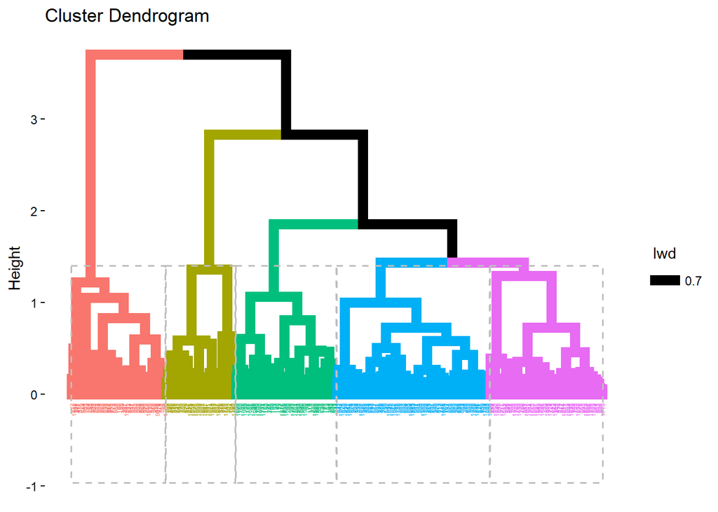

```
   clusters_hc
     1  2  3  4  5
  1  1 58  4  0  0
  2 81  3 12 26 10
  3  0  0  0  0 31
  4 14  0  5 41  4
  5  3  0 44  6  0
```

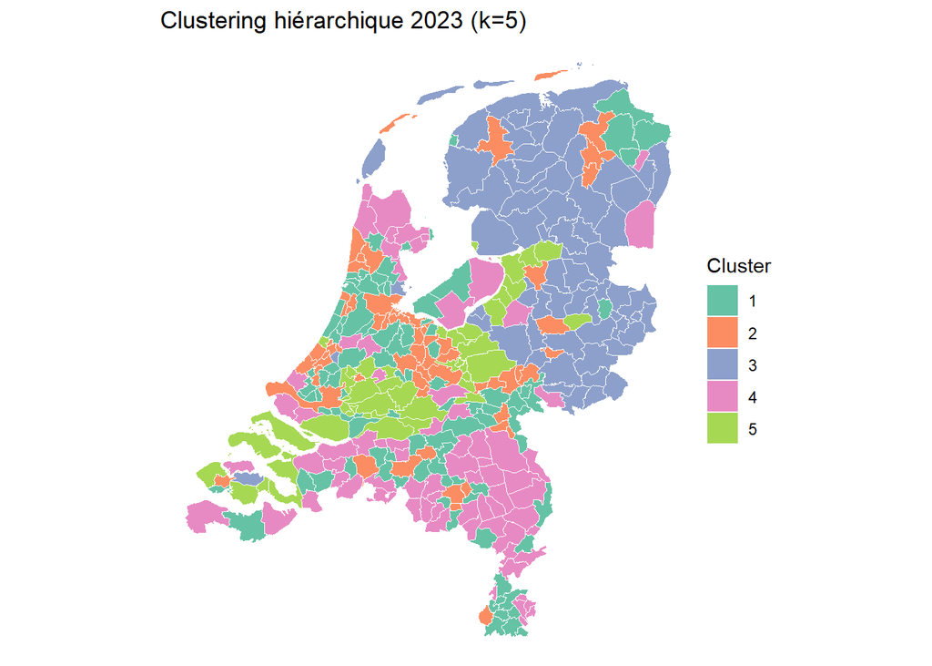

## Ajout de données socio-économiques

L’on dispose de données socio-économiques à l’échelle de la municipalité : on utilisera la densité de population, le revenu moyen (ou médian ? le terme utilisé est “gemiddeld”), la proportion de personnes issues de l’immigration, la proportion de personnes ayant une éducation supérieure (données de 2022 et 2023), et la proportion de personnes protestantes (données datant de 2014)

### k-nn, diplôme et revenu

Nous nous sommes inspirés d’une récente visualitation des résultats des dernières élections locales au Royaume-Uni produite par The Economist.

L’algorithme utilisé est un algorithme de k-nearest neighbors : on regroupe les municipalités en groupes de k, d’après une distance correspondant aux grandeurs des deux axes (diplôme et revenu), et on assigne à chaque groupe le parti arrivé dans tête dans la majorité de ce groupe.

```
  dominant   n
1  GL-PvdA  32
2     JA21  11
3      PVV 336
4      VVD  37
```

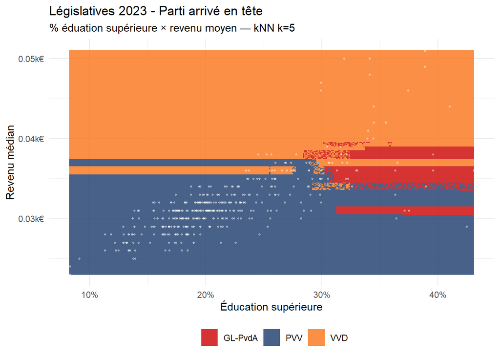

```
  dominant   n
1      CDA  53
2      D66  89
3  GL-PvdA   9
4      PVV 188
5      SGP  22
6      VVD  55
```

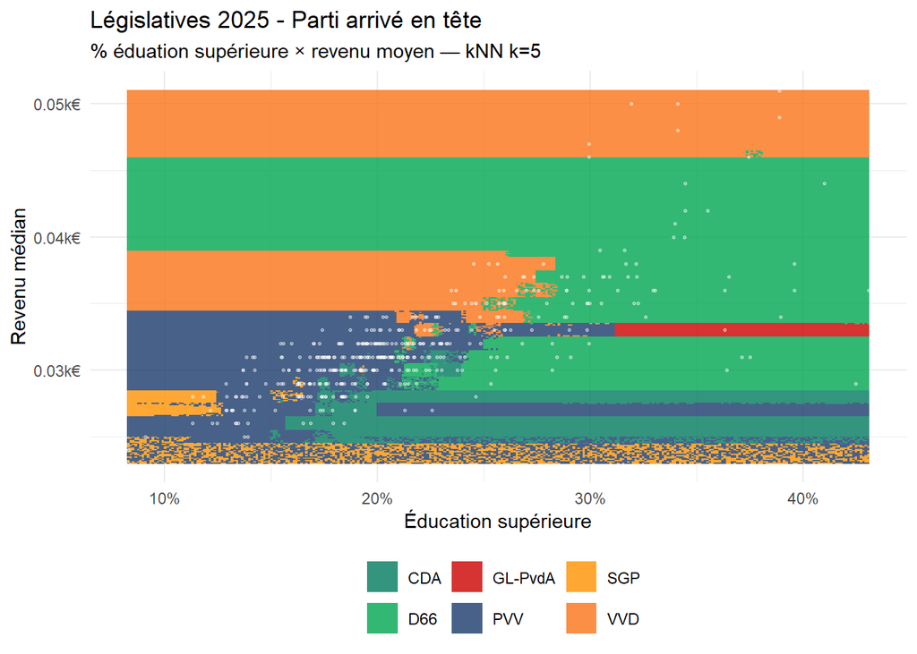

En 2023, c’est essentiellement une division entre les municipalités aux revenus élevés qui votent VVD et celles aux revenus moins élevés qui votent PVV, avec GL-PvdA en tête à revenu moyen et niveau éducatif élevé.

On observe un réalignement en 2025 : D66 domine à revenu moyen et niveau de diplôme élevé, et à revenu élevé mais pas trop non plus.

### ACP, Partie 2

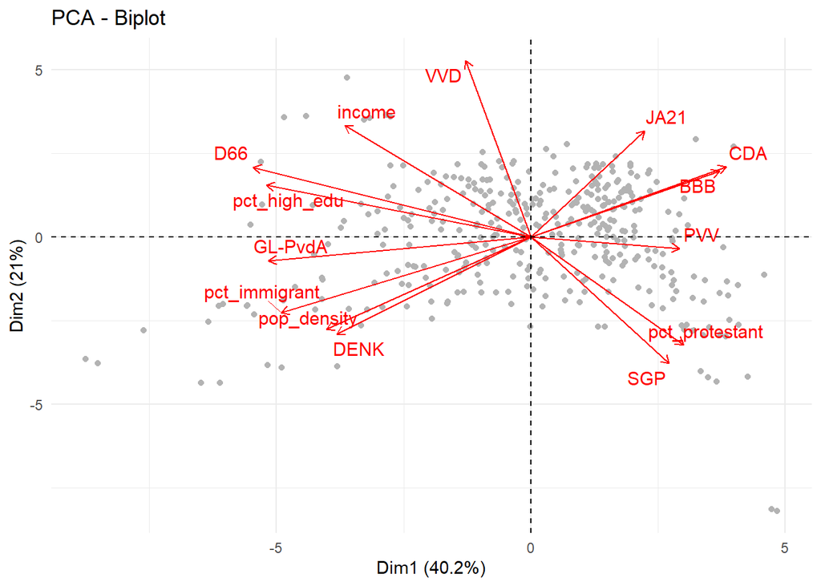

L’ajout de ces facteurs socio-économiques améliore un peu la significativité des deux premières composantes, les alignements entre les facteurs socio-économiques présents et les performances des partis sont globalement attendus.